# QTW Case Study 6

Author

Nicholas Sager

Published

July 15, 2024

## Introduction

The goal of this Case Study is to predict whether a given reading from a high-energy particle accelerator is a legitimate signal or background. The data has been generated from Monte Carlo simulations, but has been used by physicists to test machine learning methods for detecting the creation of exotic particles from collisions.

## Data Processing and Exploration

The data contains 7,000,000 records containing 28 features and the target variable, a binary label of whether the process is one that creates a Higgs Boson. The first 21 features are kinematic properties measured by the particle detectors in the accelerator, while the last 7 features are high-level features derived by physicists to help with classification. All are unlabeled except for the ‘mass’ column.

### Summary Statistics

Our dataset has two classes, signal and background. They are labelled ‘1.0’ and ‘0.0’ and are split almost evenly. There are approximately 3.5M records labelled ‘signal’ and 3.5M records labelled ‘background’.

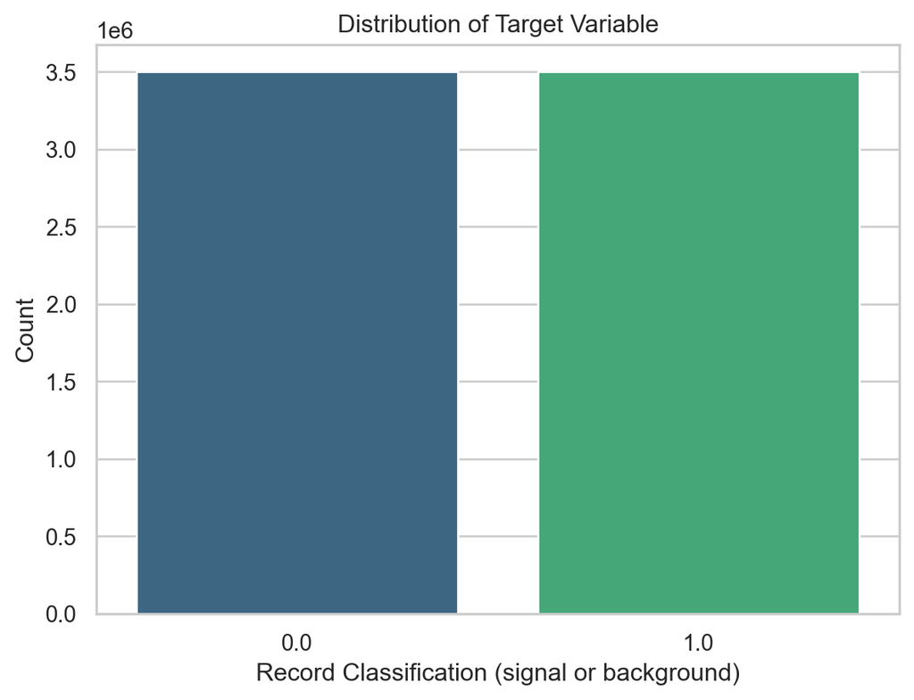

Figure 1: Distribution of Target Variable (Label). The classes are evenly distributed.

The mass variable appears to be uniformly distributed as shown in the histogram below. This is expected since the mass is a derived variable and the data is from repeated simulations.

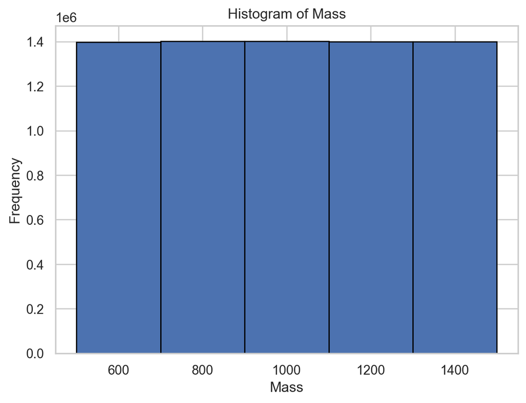

Figure 2: Distribution of Mass Variable. Mass appears to be uniformly distributed.

To better understand the distribution of the other features, we can plot a histogram of the ‘f4’ variable. The ‘f4’ variable appears to be also uniformly distributed. We could also plot histograms of other features, but for brevity, we will only show the distribution of ‘f4’.

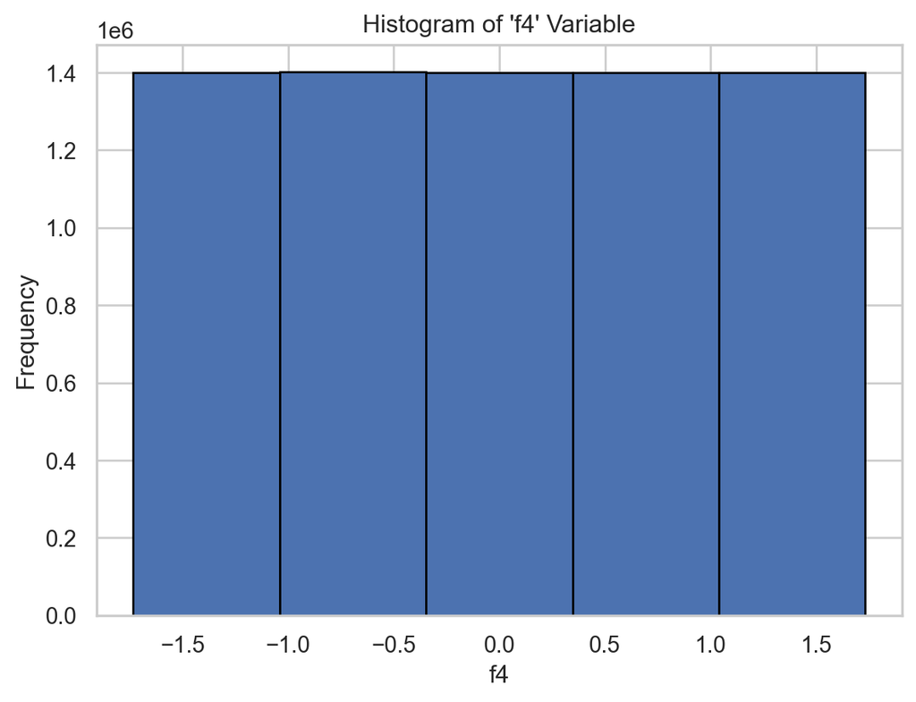

Figure 3: Distribution of F4 Variable. This variable appears to be Uniformly distributed.